主题 明暗

Generated by [Answer me with HTML](https://github.com/QingYunA/answer-me-with-html) 0.5.10 · 2026-11-03 13:08 · [★ Star on GitHub](https://github.com/QingYunA/answer-me-with-html)

# T01 Agent 实验：耗时与工具调用

dev.15 · 共同 prompt 要求合并操作、避免重复检查 · 每组三次

A1 三次均为 **6 次调用**；C1 为 **13、11、14 次**。 两组耗时中位数仅相差 **4.35 秒**。

A

## 完成三轮请求用了多久

A1 中位数 **211.31 秒**；C1 中位数 **215.66 秒**。

A1 是 Peter 持久 R 会话，C1 是原生 Codex。 按实际执行顺序展示全部六次运行。

[figure not shown]

**数据**

| A1-1 | 211.31秒 |
| --- | --- |
| C1-1 | 215.66秒 |
| C1-2 | 204.17秒 |
| A1-2 | 210.35秒 |
| A1-3 | 222.58秒 |
| C1-3 | 235.85秒 |

本页重点是 agent 执行行为。 耗时包括启动、输入加载、模型交互、工具执行与收尾。 每组仅三次，不据此宣称稳定的性能优势。

B

## Function / tool call：准确次数

[figure not shown]

**数据**

| A1-1 | 6次 |
| --- | --- |
| C1-1 | 13次 |
| C1-2 | 11次 |
| A1-2 | 6次 |
| A1-3 | 6次 |
| C1-3 | 14次 |

[figure not shown]

**数据**

|  | R 执行 | Shell 命令 | stdin 与轮询 | 写文件 | 看图 |
| --- | --- | --- | --- | --- | --- |
| A1-1 | 5次 | 0次 | 0次 | 1次 | 0次 |
| C1-1 | 0次 | 7次 | 6次 | 0次 | 0次 |
| C1-2 | 0次 | 7次 | 4次 | 0次 | 0次 |
| A1-2 | 5次 | 0次 | 0次 | 1次 | 0次 |
| A1-3 | 5次 | 0次 | 0次 | 1次 | 0次 |
| C1-3 | 0次 | 8次 | 6次 | 0次 | 0次 |

A1 按 gptr 的实际工具派发计数。 C1 按原始会话中的内部工具调用计数。 外层 exec 包装不重复累加，进度查询也计入工具调用。

本轮 C1 多出的调用涉及环境探查、stdin 交互或轮询、错误恢复。 三次 C1 各有一次工具错误；A1 没有工具错误。 A1 三次仍各有一次独立收尾检查。

这不是 R 函数内部调用次数，也不是模型 API 请求次数。 C1 的一条 Shell 命令可以同时完成计算、画图和写报告。 因此，工具次数相同不代表工作量相同。 展开每一次调用的用途和耗时。

C

## 哪一轮的调用与耗时最多

**A1：每轮调用数**

[figure not shown]

**数据**

|  | Request 1 | Request 2 | Request 3 |
| --- | --- | --- | --- |
| A1-1 | 2次 | 1次 | 3次 |
| A1-2 | 2次 | 1次 | 3次 |
| A1-3 | 2次 | 1次 | 3次 |

**A1：每轮耗时**

[figure not shown]

**数据**

|  | Request 1 | Request 2 | Request 3 |
| --- | --- | --- | --- |
| A1-1 | 56.11秒 | 41.45秒 | 104.45秒 |
| A1-2 | 61.21秒 | 41.06秒 | 98.79秒 |
| A1-3 | 56.62秒 | 40.93秒 | 115.75秒 |

**C1：每轮调用数**

[figure not shown]

**数据**

|  | Request 1 | Request 2 | Request 3 |
| --- | --- | --- | --- |
| C1-1 | 8次 | 3次 | 2次 |
| C1-2 | 7次 | 1次 | 3次 |
| C1-3 | 9次 | 1次 | 4次 |

**C1：每轮耗时**

[figure not shown]

**数据**

|  | Request 1 | Request 2 | Request 3 |
| --- | --- | --- | --- |
| C1-1 | 77.18秒 | 43.27秒 | 95.21秒 |
| C1-2 | 74.22秒 | 38秒 | 91.94秒 |
| C1-3 | 84.78秒 | 38.67秒 | 112.41秒 |

请求耗时已包含工具执行，不可再相加。 未被工具区间覆盖的时间包含生成、网络和服务等待。 不能把这些空白全部归为模型思考时间。

**A1：工具执行只占总耗时的一小部分**

[figure not shown]

**数据**

|  | 全部工具区间合计 | 总耗时 |
| --- | --- | --- |
| A1-1 | 12.27秒 | 211.31秒 |
| A1-2 | 14.59秒 | 210.35秒 |
| A1-3 | 14.27秒 | 222.58秒 |

工具变少不保证总耗时同比下降。 工具以外仍有输入加载、生成、网络与服务等待。 现有记录无法将这些等待准确拆成模型推理和网络耗时。 C1 包含异步进程，不能直接套用 A1 的区间合计口径。

D

## 保留三行概览甘特图

代表轨迹：**A1-1 与 C1-1**，取各组时长中位数对应实验。

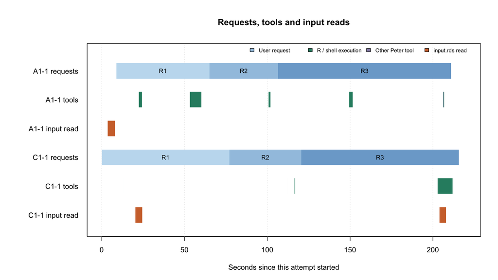

请求、工具执行、原始 input.rds 读取

每组分为请求、工具执行、原始输入读取三行。 概览只画起止端点完整的区间，不补造结束时间。 C1 的工具行是命令生命周期，含交互进程等待。 这不是纯计算时长；stdin 查询未单独画在该行。 短调用缩小后不明显，不能用肉眼数横条作为调用数。

准确次数：A1-1 为 **6 次**；C1-1 为 **13 次**。

输入读取行只显示 input.rds，不包含其他缓存文件。 逐项调用明细。

E

## 额外开销：错误恢复与缓存读写

**工具错误，包含后来恢复成功的错误**

[figure not shown]

**数据**

| A1-1 | 0次 |
| --- | --- |
| C1-1 | 1次 |
| C1-2 | 1次 |
| A1-2 | 0次 |
| A1-3 | 0次 |
| C1-3 | 1次 |

**RDS 读写耗时，含缓存文件**

[figure not shown]

**数据**

|  | 读取与反序列化 | 写出与序列化 |
| --- | --- | --- |
| A1-1 | 4.33秒 | 0秒 |
| C1-1 | 8.14秒 | 0秒 |
| C1-2 | 12.57秒 | 6.82秒 |
| A1-2 | 4.31秒 | 0秒 |
| A1-3 | 4.33秒 | 0秒 |
| C1-3 | 21.09秒 | 10.46秒 |

这些耗时已计入任务总时间，不是额外加上去的成本。 统计包括已记录的 RDS 操作，不等于纯磁盘 I/O。 操作系统缓存没有清空。

**C1-1**：13 次内部工具调用，分布为 8 / 3 / 2。第三轮已合并执行；第二轮仍发生一次跨请求复用交互式 R 进程失败，并自行恢复。

**C1-2**：11 次调用，分布为 7 / 1 / 3。一次 raw 对象判断错误后重跑。原始文件只读一次，但大矩阵缓存又读了两次；不能仅按 input.rds 次数判断数据复用。

**C1-3**：14 次调用：8 次命令、6 次进度查询。Request 1 的矩阵类型检查误判，修正后重跑；Request 3 重新读取原始矩阵，并查询进度三次。

F

## 实验范围与证据

本轮两组读取同一份用户 prompt，模型与输入数据相同。 源码在六次运行期间固定；没有用重跑替换本轮记录。 采集期间有轻量状态查询与已完成产物下载。

按本次要求，报告不展开 biomedical 结果评分。 执行完成不等于科学正确：A1-1 已发现 marker 使用 QC 后细胞。 本轮未完成六次结果的独立科学复算，不宣称全部科学通过。

六次原始结果 · 共同 prompt · 逐项调用 · C1 原始工具计数 · 请求计时 · RDS 操作统计 · 输入与版本 · 本地/AWS 源码核对